# Métodos Computacionais II

2018/2

[Jony Arrais Pinto Junior](http://lattes.cnpq.br/4940428746026448)

## 1 - Conteúdo Aula 07

- Integrais;
- Derivadas;
- Maximizando funções no R;
- Verificando alguns resultados teóricos por meio de simulação.

## 2 - Integrais

Podemos usar o R para obter respostas numéricas de uma integral.

### 2.1 - Integração em uma dimensão

Suponha que desejamos calcular a seguinte integral
$$\int_{0}^{0.1}5e^{-5x}I(x>0)dx.$$

```r
funcao = function(x){
  valor = 5*exp(-5*x)*I(x>0)
  return(valor)
}
```

Como obter a área da integral acima?

```r
integrate(funcao, lower = 0, upper = 0.1)
```

```
## 0.3934693 with absolute error < 4.4e-15
```

Será que o valor obtido acima está correto? O que sabemos sobre a função “funcao” criada?

```r
pexp(0.1, rate = 5)
```

```
## [1] 0.3934693
```

```r
integrate(funcao, lower = 0, upper = Inf)
```

```
## 1 with absolute error < 2.3e-06
```

### 2.2 - Integração em uma função multidimensional

Suponha agora a seguinte função
$$\int_{0}^{1/2}\int_{0}^{1/2}\int_{0}^{1/2}\frac{2}{3}(x_1 + x_2 + x_3)dx_1 dx_2 dx_3.$$

```r
library(cubature)

funcao.mult = function(x){
  valor = 2/3 * (x[1] + x[2] + x[3])
  return(valor)
}
```

Para obtermos o valor da integral desejada, basta usarmos os seguintes comandos:

```r
adaptIntegrate(funcao.mult, lowerLimit = c(0, 0, 0), upperLimit = c(0.5, 0.5, 0.5))
```

```
## $integral
## [1] 0.0625
##
## $error
## [1] 1.387779e-17
##
## $functionEvaluations
## [1] 33
##
## $returnCode
## [1] 0
```

## 2 - Derivadas

Podemos também realizar operações de derivação no R. Suponha que desejamos calcular
$$\frac{d(e^{-x} cos(x) y +3y^2x)}{dx}.$$

```r
#Primeiro usamos o quote para criar a função
f = quote(exp(-x)*cos(x)*y + 3*y^2*x)

#Visualizando f
f
```

```
## exp(-x) * cos(x) * y + 3 * y^2 * x
```

```r
#Depois usamos a funçao D para derivar
df.dx = D(f,"x")

#Visualizando o resultado da derivação
df.dx
```

```
## 3 * y^2 - (exp(-x) * sin(x) + exp(-x) * cos(x)) * y
```

E se desejarmos obter a derivada segunda?

```r
D(df.dx, "x")
```

```
## -((exp(-x) * cos(x) - exp(-x) * sin(x) - (exp(-x) * sin(x) +
##     exp(-x) * cos(x))) * y)
```

Se quiséssemos calcular
$$\frac{\partial^2(e^{-x} cos(x) y +3y^2x)}{\partial x \partial y}.$$

```r
D(df.dx, "y")
```

```
## 3 * (2 * y) - (exp(-x) * sin(x) + exp(-x) * cos(x))
```

## 3 - Maximizando funções no R

Suponha que estamos interessado em maximizar a função
$$f(x) = 2 - (x - 3)^2, \qquad -3 < x < 5.$$

Podemos incialmente explorar a função com um gráfico.

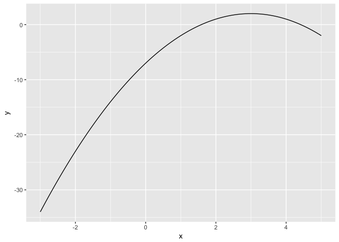

```r
#Criando a função
fun.max = function(x){
  valor = 2 - (x - 3)^2
  return(valor)
}

#Plotando a função
library(ggplot2)

ggplot(data = data.frame(x = c(-3,5)), aes(x = x)) + stat_function(fun = fun.max)
```

Para obtermos o máximo, basta utilizarmos a função optimise.

```r
#Obtendo o máximo
maximo = optimise(fun.max,c(-3,5), maximum = TRUE)

#Visualizando o máximo
maximo
```

```
## $maximum
## [1] 3
##
## $objective
## [1] 2
```

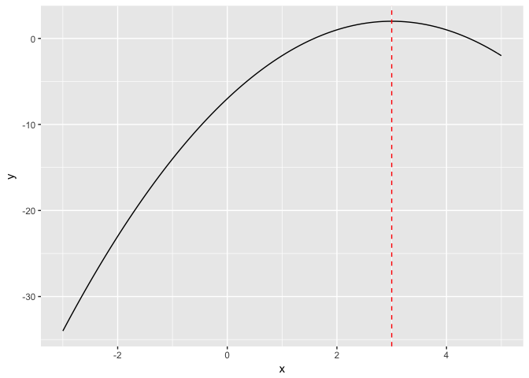

```r
#Apresentando o máximo no gráfico
ggplot(data = data.frame(x = c(-3,5)), aes(x = x)) + stat_function(fun = fun.max) + geom_vline(aes(xintercept = maximo$maximum), linetype = "dashed", color = "red" )
```

Qual o nosso principal interesse em maximizar funções?

Suponha que estamos interessados em encontrar a estimativa de máxima verossimilhança do parâmetro $\lambda$ da distribuição de Poisson, se foi observada uma amostra com os seguintes valores
$$z = c(2,3,1,2,3,4,5,3,3,1).$$

Basta seguirmos os passos abaixo:

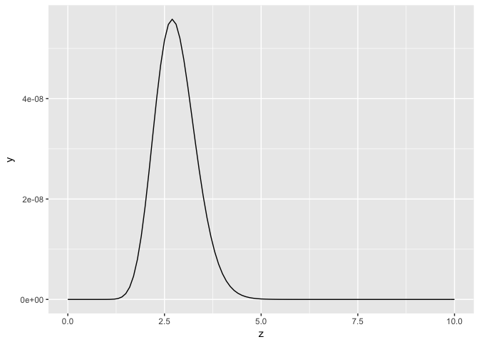

```r
#Criando a função
ver = function(l,z){
  valor = exp(-l*length(z))*l^{sum(z)}*prod(1/factorial(z))
}

#Obtendo o gráfico da função de verossimilhança
ggplot(data = data.frame(x = c(0,10)), aes(x = x)) + stat_function(fun = ver, args = list(z = c(2,3,1,2,3,4,5,3,3,1))) + xlab("z")
```

```r
#Obtendo a estimativa de máxima verossimilhança
EMV = optimise(ver,c(0,100),maximum = TRUE,  z=c(2,3,1,2,3,4,5,3,3,1))

EMV
```

```
## $maximum
## [1] 2.699999
##
## $objective
## [1] 5.5823e-08
```

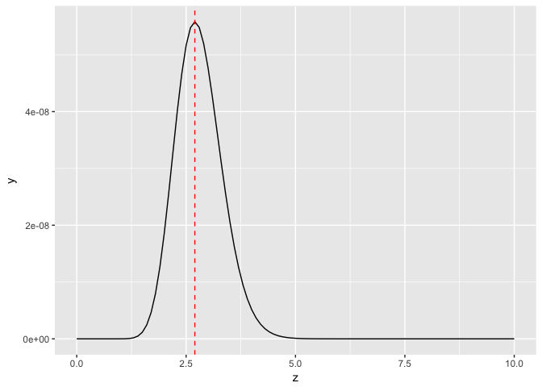

```r
#Acresentando a estimativa no gráfico (OBS: no curve, x é sempre o que varia, mesmo que na função você tenha denotado ele por uma outra leytra, precisa chamálo de x no curve)
#Obtendo o gráfico da função de verossimilhança
ggplot(data = data.frame(x = c(0,10)), aes(x = x)) + stat_function(fun = ver, args = list(z = c(2,3,1,2,3,4,5,3,3,1))) + xlab("z")  + geom_vline(aes(xintercept = EMV$maximum), linetype = "dashed", color = "red" )
```

## 4 - Verificando resultados teóricos por meio de simulação

### 4.1 - Transformações de variáveis

Seja $X \sim N(0,1)$ e $Y \sim \chi_{(10)}$. Qual a distribuição de
$$\dfrac{X}{\sqrt{Y/10}}?$$

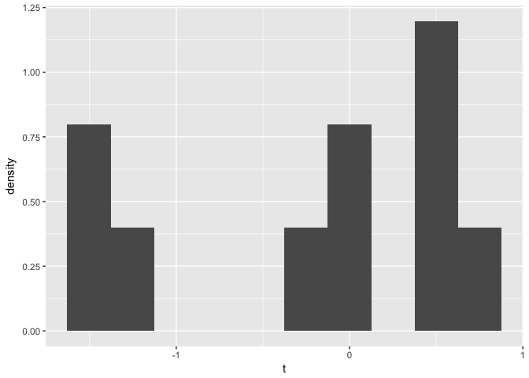

```r
#Vamos checar esse resultado numericamente. Vamos definir um n
n = 10

#Gere uma amostra de X
normal = rnorm(n)

#Gere uma amostra de Y
qui = rchisq(n,10)

#Obtenha o valor da transformação
base2 = data.frame(t = normal/sqrt(qui/10))

#Vamos visualizar graficamente
ggplot(data = base2, aes(x = t)) + geom_histogram(aes(y = ..density..), bins = 10)
```

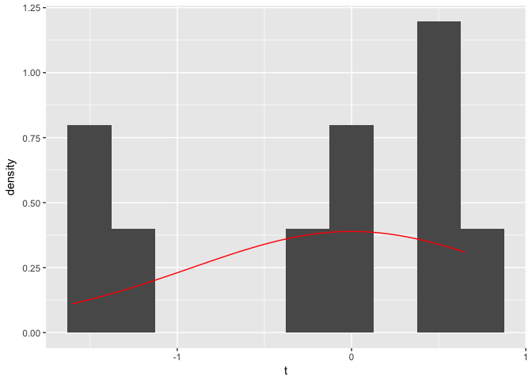

```r
#Se soubermos a distribuição da transformação, podemos acresentá-la nos valores obtidos com a transformação para checar se o resultado se aproxima
ggplot(data = base2, aes(x = t)) + geom_histogram(aes(y = ..density..), bins = 10) + stat_function(fun = dt, args = list(df = 10), col = "red")
```

Será que 10 valores é suficiente para visualizarmos o resultado numericamente?

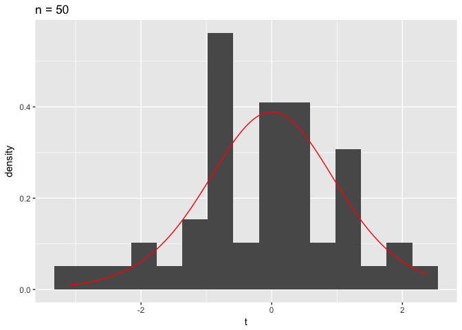

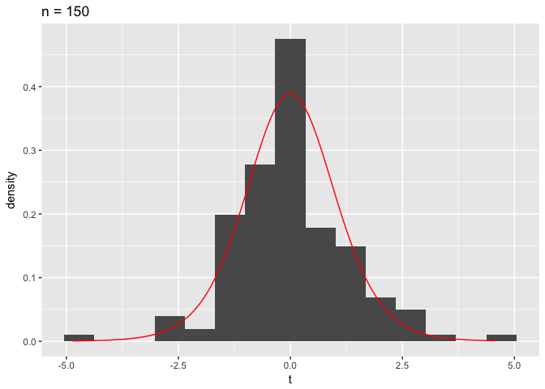

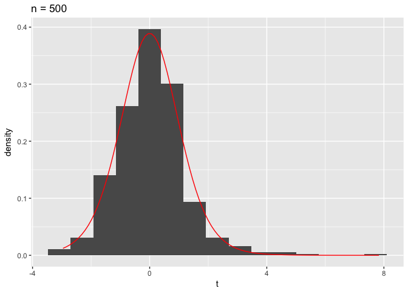